# RepData_Assignment1

### Loading libraries

```r
library(plyr)
library(ggplot2)
library(lattice)
```

### Loading and preprocessing the data

```r
data <- read.csv("activity.csv", header = T, sep = ',')
data.RemoveNa <- subset(data, is.na(data$steps) == F)
```

### What is mean total number of steps taken per day?

#### 1. Make a histogram of the total number of steps taken each day

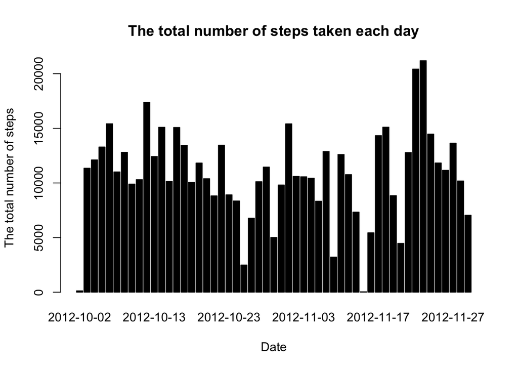

```r
# Calculate the total number of steps per day
totalStepsPerDay <- ddply(
    data.RemoveNa, .(date), summarise, totalSteps=sum(steps))
# create the plot
barplot(totalStepsPerDay$totalSteps, names.arg = totalStepsPerDay$date,
        col = "black", main = "The total number of steps taken each day",
        xlab = "Date", ylab = "The total number of steps")
```

#### 2. Calculate the mean and median total number of steps taken per day

The mean number of steps taken per day

```r
mean(totalStepsPerDay$totalSteps)
```

```
## [1] 10766
```

The median number of steps taken per day

```r
median(totalStepsPerDay$totalSteps)
```

```
## [1] 10765
```

### What is the average daily activity pattern?

#### 1. Make a time series plot of the 5-minute interval (x-axis) and

#### the average number of steps taken, averaged across all days (y-axis)

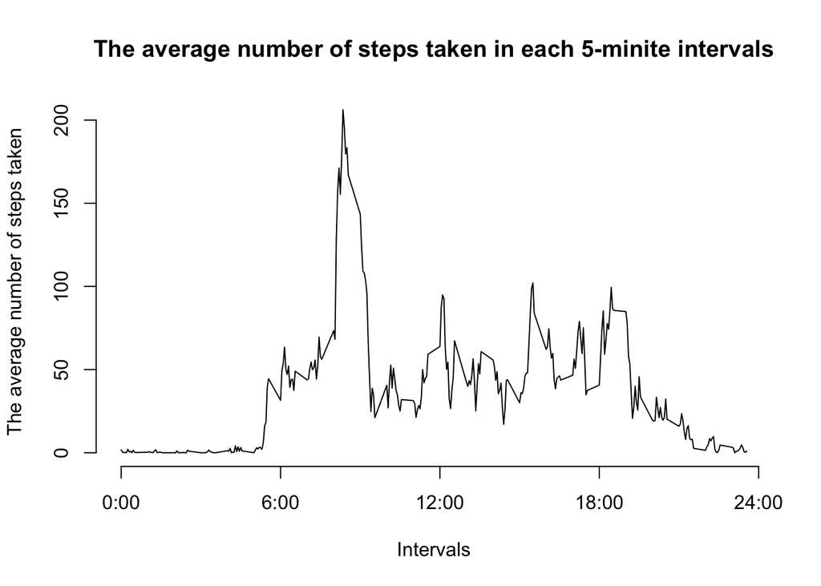

```r
# Calcluating the average number of steps taken in each 5-minite intervals
avg.PerInterval <- ddply(data.RemoveNa, .(interval),
                         summarise, meanSteps = (mean(steps)))
# create the plot
plot(avg.PerInterval$interval, avg.PerInterval$meanSteps, axes = F, type = "l",
     col = "Black",
     main = "The average number of steps taken in each 5-minite intervals",
     xlab = "Intervals",
     ylab = "The average number of steps taken")
axis(1,
     at=c(0, 600, 1200, 1800, 2400),
     label = c("0:00", "6:00", "12:00", "18:00", "24:00"))
axis(2)
```

#### 2. Which 5-minute interval, on average across all the days in the dataset,

#### contains the maximum number of steps?

```r
interval.maxMeanSteps <- avg.PerInterval[which.max(avg.PerInterval$meanSteps),]
interval <- interval.maxMeanSteps$interval
maxMeanSteps <- interval.maxMeanSteps$meanSteps
fromhour <- as.integer(interval/100)
frommin <- interval%%100
if (frommin >= 55){
    tohour <- fromhour + 1
    tomin <- (frommin + 5) %% 60
} else {
    tohour <- fromhour
    tomin <- frommin + 5
}
```

So the interval that contains the maximum number of step is 8:35 – 8:40, and the average steps is 206.1698.

### Imputing missing values

#### 1. Calculate and report the total number of missing values in the dataset

```r
sum(is.na(data$steps))
```

```
## [1] 2304
```

#### 2. Devise a strategy for filling in all of the missing values

#### 3. Create a new dataset that is equal to the original dataset

#### but with the missing data filled in

```r
data.impute <- data
for (i in 1:nrow(data.impute)){
    if (is.na(data.impute$steps[i]))
        data.impute$steps[i] <-
            avg.PerInterval$meanSteps[
                which(data.impute$interval[i] == avg.PerInterval$interval)]
}
head(data.impute)
```

```
##     steps       date interval
## 1 1.71698 2012-10-01        0
## 2 0.33962 2012-10-01        5
## 3 0.13208 2012-10-01       10
## 4 0.15094 2012-10-01       15
## 5 0.07547 2012-10-01       20
## 6 2.09434 2012-10-01       25
```

#### 4. Make a histogram of the total number of steps taken each day and

#### Calculate the mean and median total number of steps taken per day.

#### Do these values differ from the estimates from the first part of the

#### assignment? What is the impact of imputing missing data on the estimates

#### of the total daily number of steps?

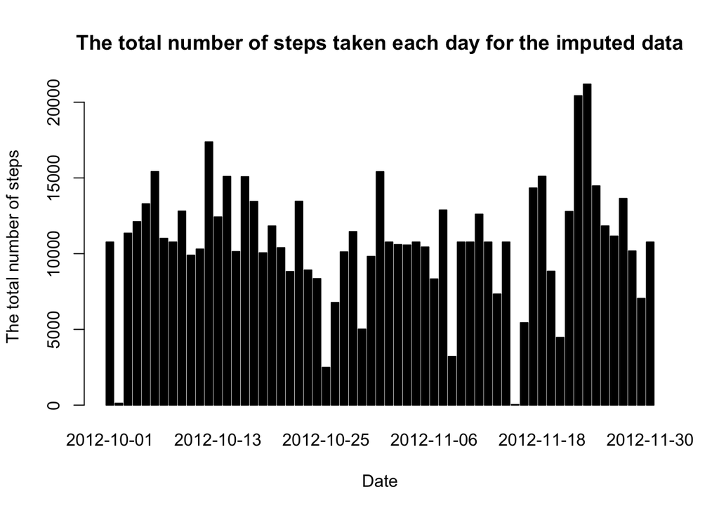

```r
# Calculate the total number of steps per day for the imputed data
totalStepsPerDay.impute <- ddply(data.impute, .(date),
                                   summarise, totalSteps = sum(steps))

# create the plot for the imputed data
barplot(totalStepsPerDay.impute$totalSteps,
        names.arg = totalStepsPerDay.impute$date,
        col = "black",
        main = "The total number of steps taken each day for the imputed data",
        xlab = "Date", ylab = "The total number of steps")
```

Calculate and report the mean and median total number of steps taken per day for the imputed data

```r
mean(totalStepsPerDay.impute$totalSteps)
```

```
## [1] 10766
```

```r
median(totalStepsPerDay.impute$totalSteps)
```

```
## [1] 10766
```

Differences between the values for the imputed data and the ones for the origin ones

```r
mean(totalStepsPerDay.impute$totalSteps) - mean(totalStepsPerDay$totalSteps)
```

```
## [1] 0
```

```r
median(totalStepsPerDay.impute$totalSteps) - median(totalStepsPerDay$totalSteps)
```

```
## [1] 1.189
```

```r
sum(totalStepsPerDay.impute$totalSteps) - sum(totalStepsPerDay$to)
```

```
## [1] 86130
```

So the mean didn’t change after the imputing, and the median only slightly changed, but the total steps increased.

### Are there differences in activity patterns between weekdays and weekends?

#### 1. Create a new factor variable in the dataset with two levels –

#### “weekday” and “weekend” indicating whether a given date is a weekday or

#### weekend day.

```r
Sys.setlocale("LC_TIME", "Chinese")
```

```
## [1] ""
```

```r
dates <- weekdays(as.Date(data.impute$date))
data.impute$dayType <-
    ifelse(dates %in%
               c("Saturday", "Sunday"), "weekend", "weekday")
```

#### 2.Make a panel plot containing a time series plot of the 5-minute interval

#### and the average number of steps taken, averaged across all weekday days or

#### weekend days.

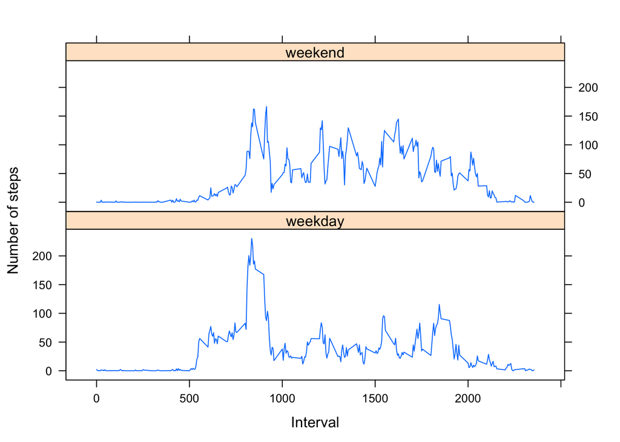

```r
# calcluate the average for each interval
avgSteps.byDayType <- ddply(data.impute, .(interval, dayType),
                            summarise, meanSteps = mean(steps))

# create the plot
xyplot(meanSteps ~ interval | dayType,
       data = avgSteps.byDayType,
       layout = c(1, 2),
       type = "l",
       xlab = "Interval",
       ylab = "Number of steps")
```

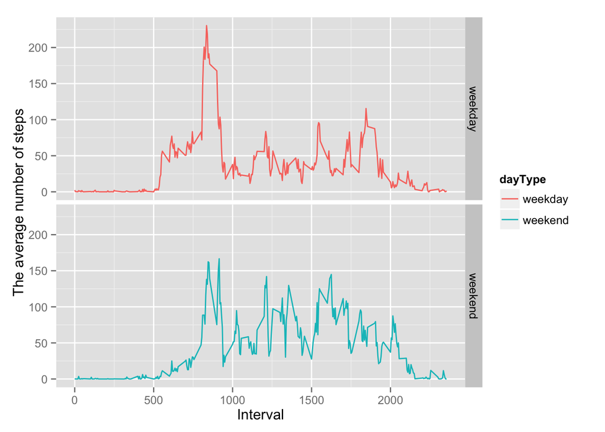

```r
g <- ggplot(avgSteps.byDayType, aes(interval, meanSteps))
g + facet_grid(dayType~.) +
    labs(x = "Interval") +
    labs(y = "The average number of steps") +
    geom_line(aes(color = dayType))
```